# Análise Preditiva de Incêndios Florestais no Estado do RJ

Carregando Bibliotecas

```r
library(ggmap)
```

### OBJETIVOS

Está analise consiste na utilização de observações de queimadas e incêndios florestais feitas pelo INPE (Instituto Nacional de Pesquisas Espaciais) em conjunto com observações de estações meteorológicas convencionais do INMET( Instituto Nacional de Meteorologia) na tentativa de obter correlações entre as queimadas e incêndios florestais e as condições meteorológicas de forma a predizer quando ocorrerá um evento.

### Base de dados

#### **Conjunto de dados: Focos**

Foi utilizada um série temporal extraída do Banco de Dados de queimadas do INPE (https://prodwww-queimadas.dgi.inpe.br/bdqueimadas) no formato CSV contendo dados do dia 01/01/2010 até 31/12/2016 com as seguintes colunas:

- DataHora - Data e hora da detecção do foco
- Satelite - Nome do satélite de referência
- Pais - País da detecção
- Estado - estado da detecção
- Municipi - município da detecção
- Bioma - bioma da detecção
- DiaSemCh - A quantos dias a referida área está sem chuvas
- Precipit - Precipitação no momento da detecção
- RiscoFog - Risco de Fogo calculado para a área
- Latitude - Latitude do foco
- Longitud - Longitude do foco
- AreaIndu - Determina se a área do foco é industrial
- FRP - Potência Radiativa do Fogo

O Dataset possui alguns focos duplicados, o que se deve ao fato de vários satélites detectarem o mesmo foco de queimada. Dimensões do conjunto de dados - 8.618.991 linhas e 13 colunas

```r
load(file = "./dados/focos(bruto).RData")
summary(focos)
```

```
    DataHora                        Satelite               Estado                      Municipio                  Bioma
 Min.   :2010-01-01 01:21:19   NPP_375  :2179720   Mato Grosso:1458491   Corumba            : 139875   Amazonia      :3518671
 1st Qu.:2012-09-05 20:30:00   AQUA_M-T :1298271   Para       :1375685   Sao Felix do Xingu : 109370   Caatinga      : 562722
 Median :2015-05-25 04:46:53   NPP      : 800944   Maranhao   :1197028   Porto Velho        : 106089   Cerrado       :3717535
 Mean   :2014-05-24 06:48:19   GOES-12  : 667737   Tocantins  : 842952   Altamira           : 105715   Mata Atlantica: 564997
 3rd Qu.:2015-12-12 16:26:44   TERRA_M-T: 625269   Piaui      : 588302   Lagoa da Confusao  :  88226   Pampa         :  19805
 Max.   :2016-12-31 23:00:00   NOAA-18  : 504016   Bahia      : 583981   Formoso do Araguaia:  67725   Pantanal      : 235223
                               (Other)  :2543034   (Other)    :2572552   (Other)            :8001991   NA's          :     38
  DiasSemChuva     Precipitacao       RiscoFogo        Latitude         Longitude
 Min.   : -2.00   Min.   :  -2.00   Min.   :  0.0   Min.   :-33.671   Min.   :-73.99
 1st Qu.:  2.00   1st Qu.:   0.00   1st Qu.:  0.8   1st Qu.:-13.050   1st Qu.:-54.68
 Median :  7.00   Median :   3.10   Median :  1.0   Median : -9.683   Median :-49.38
 Mean   : 19.55   Mean   :  17.56   Mean   : 13.0   Mean   :-10.024   Mean   :-50.37
 3rd Qu.: 29.00   3rd Qu.:  21.20   3rd Qu.:  1.0   3rd Qu.: -5.917   3rd Qu.:-45.42
 Max.   :120.00   Max.   :1539.20   Max.   :777.7   Max.   :  5.230   Max.   :-34.80
```

#### **Conjunto de dados: Meteorologia**

Foram utilizados dados de estações meteorológicas convencionais obtidos através do Banco de Dados Meteorológicos para Ensino e Pesquisa (http://www.inmet.gov.br/projetos/rede/pesquisa/) contendo uma série temporal do dia 01/01/2010 ao dia 31/12/2016.

- Estacao – Código da estação convencional
- Data – Data da medição
- Hora – Hora da medição
- TempBulboSeco – temperatura medida com termômetro de bulbo seco
- TempBulboUmido – temperatura medida com termômetro de bulbo úmido
- UmidadeRelativa – umidade relativa do ar
- PressaoAtmEstacao – pressão atmosférica no nível da estação
- VelocidadeVento – velocidade do vento no momento da medição
- Nebulosidade – nebulosidade no momento da medição
- Latitude – Latitude da estação
- Longitude – Longitude da estação

Dimensões do conjunto de dados – 1.781.719 linhas e 11 colunas

```r
load(file = "./dados/meteo(bruto).RData")
summary(meteo)
```

```
    Estacao           Data                 Hora        TempBulboSeco   TempBulboUmido   UmidadeRelativa PressaoAtmEstacao
 Min.   :82024   Min.   :2010-01-01   Min.   :   0.0   Min.   :-6.00   Min.   :-4.60    Min.   :  8.0   Length:1781719
 1st Qu.:82693   1st Qu.:2011-08-25   1st Qu.:   0.0   1st Qu.:22.60   1st Qu.:19.00    1st Qu.: 58.0   Class :character
 Median :83270   Median :2013-04-25   Median :1200.0   Median :25.80   Median :21.80    Median : 73.0   Mode  :character
 Mean   :83158   Mean   :2013-05-15   Mean   : 977.2   Mean   :25.43   Mean   :21.22    Mean   : 70.8
 3rd Qu.:83589   3rd Qu.:2015-01-22   3rd Qu.:1800.0   3rd Qu.:28.60   3rd Qu.:24.00    3rd Qu.: 86.0
 Max.   :83997   Max.   :2016-12-31   Max.   :1800.0   Max.   :44.90   Max.   :37.80    Max.   :100.0
                                                       NA's   :14513   NA's   :287610   NA's   :15983
 VelocidadeVento   Nebulosidade       Latitude        Longitude
 Min.   : 0.00    Min.   : 0.000   Min.   :-33.51   Min.   :-72.66
 1st Qu.: 0.70    1st Qu.: 2.500   1st Qu.:-20.03   1st Qu.:-51.13
 Median : 1.50    Median : 6.000   Median :-13.43   Median :-45.94
 Mean   : 1.82    Mean   : 5.508   Mean   :-13.86   Mean   :-46.85
 3rd Qu.: 3.00    3rd Qu.: 9.000   3rd Qu.: -6.97   3rd Qu.:-41.48
 Max.   :25.72    Max.   :12.500   Max.   :  2.82   Max.   :-34.86
 NA's   :160978   NA's   :9127
```

### Seleção dos dados

O conjunto de dados Focos não utilizará as colunas “AreaIndu” e “FRP” pois as mesmas estão vazias e não utilizará também a coluna “Pais” já todos os dados se referem apenas ao Brasil.

O dois conjuntos serão filtrados para conterem somente os dados referentes ao estado do Rio de Janeiro. O conjunto focos será filtrado pela coluna Estado, a qual poderá ser removida justamente pois se tornará redundante. O conjunto meteo será filtrado através das estações 83738, 83049, 83743, 83718, 83698 e 83695 localizadas respectivamente em Resende, Paty do Alferes, Rio de janeiro, Cordeiro, Campos dos Goytacazes e Itaperuna, a localização das estações foi obtida através do site do INMET.

```r
focos_rj <- focos %>%
    filter(Estado == "Rio de Janeiro") %>%
    select(-Estado)
100-(dim(focos_rj)[1]/dim(focos)[1]*100)
```

```
[1] 99.73055
```

A primeira filtragem do conjunto focos reduziu o número de observações de 8.618.991 para apenas 23.224, uma redução de 99.73% do dataset.

```r
meteo_rj <- meteo %>%
    filter(Estacao == 83049 | Estacao == 83738 | Estacao ==  83743 |
               Estacao == 83718 | Estacao == 83698 | Estacao == 83695) %>%
    mutate(mes = format(.[["Data"]], "%m"), ano = format(.[["Data"]], "%Y"))
100-(dim(meteo_rj)[1]/dim(meteo)[1]*100)
```

```
[1] 97.61208
```

A primeira filtragem do conjunto meteo reduziu o número de observações de 1.781.719 para apenas 42.546, uma redução de 97.61% do dataset, além disso foram acrescentadas duas colunas, “mes” e “ano”.

### Qualidade e Limpeza dos dados

#### Limpeza do conjunto de dados Meteo

##### Verificando as observações faltantes

```r
sapply(meteo_rj, function(x)(sum(is.na(x))))
```

```
          Estacao              Data              Hora     TempBulboSeco    TempBulboUmido   UmidadeRelativa PressaoAtmEstacao
                0                 0                 0                63              1746                46              7405
  VelocidadeVento      Nebulosidade          Latitude         Longitude               mes               ano
             3791                46                 0                 0                 0                 0
```

##### Checando a frequencia das estacoes por ano

```r
freq_table <- xtabs(~ano+Estacao, data=meteo_rj) %>%
      t(.)
freq_table <- reshape(as.data.frame(freq_table), timevar = "ano", idvar = "Estacao", direction = "wide")
head(freq_table[which(freq_table == 0, arr.ind = TRUE)[,1],])
```

| Estacao | Freq.2010 | Freq.2011 | Freq.2012 | Freq.2013 | Freq.2014 | Freq.2015 | Freq.2016 |
| --- | --- | --- | --- | --- | --- | --- | --- |

Todas as estações tem dados para todos os anos.

##### Distribuição de Valores faltantes por ano

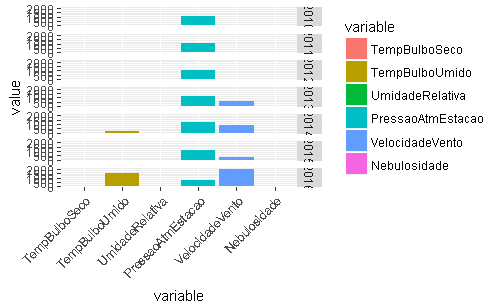

```r
aggregate(. ~ ano, data=meteo_rj, function(x) {sum(is.na(x))}, na.action = NULL) %>%
      melt() %>%
      filter (value > 0) %>%
      ggplot(data = . , aes(variable, value, fill = variable)) +
      geom_bar(stat = "identity") + facet_grid(ano ~ .) +
      theme(axis.text.x = element_text(angle = 45, hjust = 1))
```

##### Distribuição de valores faltantes por estação

```r
meteo_rj$Estacao <- as.factor(meteo_rj$Estacao)
aggregate(. ~ Estacao, data=meteo_rj, function(x) {sum(is.na(x))}, na.action = NULL) %>%
      melt() %>%
      filter(value > 0) %>%
      ggplot(data = . , aes(variable, value, fill = variable)) +
      geom_bar(stat = "identity") + facet_grid(Estacao ~ .) +
      theme(axis.text.x = element_text(angle = 45, hjust = 1))
```

[output not shown]

```r
paste("Valores faltantes:",
      sum(is.na(meteo_rj[meteo_rj$Estacao == 83049, "PressaoAtmEstacao"])))
```

```
[1] "Valores faltantes: 7034"
```

```r
paste("Total de observações:", dim(meteo_rj[meteo_rj$Estacao == 83049, ])[1])
```

```
[1] "Total de observações: 7034"
```

Podemos perceber que a estação 83049 possui todas observações para PressaoAtm vazias, desse modo, para que a análise não seja muito prejudicada, excluíremos essa coluna.

```r
meteo_rj$PressaoAtmEstacao <- NULL
names(meteo_rj)
```

```
 [1] "Estacao"         "Data"            "Hora"            "TempBulboSeco"   "TempBulboUmido"  "UmidadeRelativa"
 [7] "VelocidadeVento" "Nebulosidade"    "Latitude"        "Longitude"       "mes"             "ano"
```

```r
paste("Valores faltantes:",
      sum(is.na(meteo_rj[meteo_rj$Estacao == 83743, "VelocidadeVento"])))
```

```
[1] "Valores faltantes: 2094"
```

```r
paste("Total de observações:", dim(meteo_rj[meteo_rj$Estacao == 83743, ])[1])
```

```
[1] "Total de observações: 7632"
```

Podemos perceber que a estação 83743 apesar de ter um grande número de valores faltantes na coluna VelocidadeVento, a maior parte das observações está lá. Utilizaremos o pacote MICE para realizar a imputação dos dados faltantes.

##### Imputação dos valores faltantes através de imputação multivariada por equações em cascata (pacote mice)

```r
ini <- meteo_rj %>%
      select(c("TempBulboSeco", "TempBulboUmido", "VelocidadeVento",
               "UmidadeRelativa", "Nebulosidade")) %>%
      mice(data = ., maxit = 0, seed = 1869)

imp_merged <- mice.mids(ini, maxit = 3)
meteo_rj_imputado <- complete(imp_merged)
```

##### Comparando a distribuição das variáveis antes e depois da imputação.

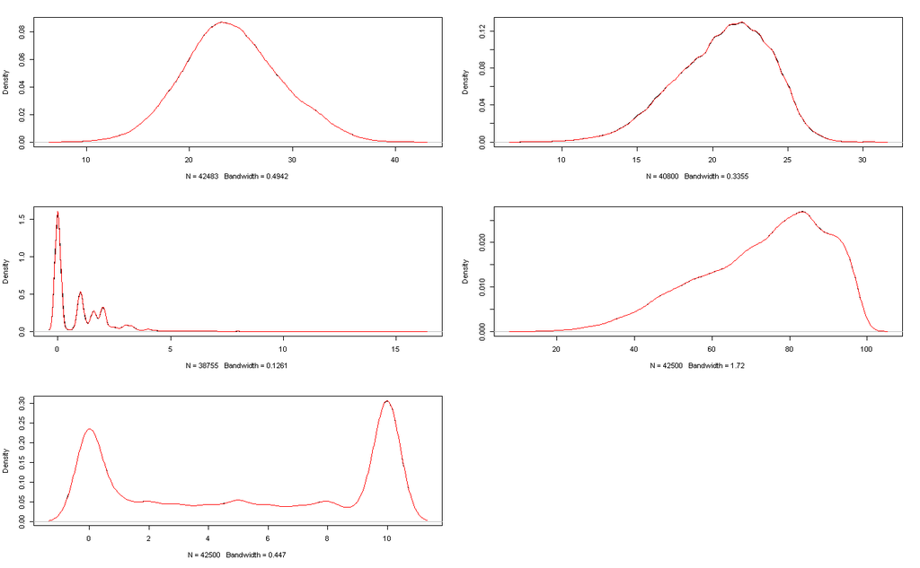

```r
# Pequena função para auxiliar na plotagem
plot.multi.dens <- function(s)
{
      junk.x = NULL
      junk.y = NULL
      for(i in 1:length(s)) {
            junk.x = c(junk.x, density(s[[i]])$x)
            junk.y = c(junk.y, density(s[[i]])$y)
      }
      xr <- range(junk.x)
      yr <- range(junk.y)
      plot(density(s[[1]]), xlim = xr, ylim = yr, main = "")
      for(i in 1:length(s)) {
            lines(density(s[[i]]), xlim = xr, ylim = yr, col = i)
      }
}
par(mfrow = c(3, 2))
for (i in names(meteo_rj_imputado)){
      plot.multi.dens(list(cc(meteo_rj[[i]]), meteo_rj_imputado[[i]]))
}
```

##### Substituindo os valores antigos pelos novos

```r
for ( i in names(meteo_rj_imputado)){
      meteo_rj[[i]] <- meteo_rj_imputado[[i]]
}
rm("meteo", "meteo_rj_imputado", imp_merged, ini, freq_table)
```

```
object 'imp_merged' not foundobject 'ini' not found
```

#### Limpeza do conjuto Focos

##### Checando a existência de valores faltantes

```r
paste("Valores faltantes:", sum(is.na(focos_rj)))
```

```
[1] "Valores faltantes: 0"
```

##### Criando Colunas

Criando duas colunas, “mes” e “ano” para facilitar a análise.

```r
focos_rj <- focos_rj %>%
      mutate(mes = format(DataHora, "%m"),
             ano = format(DataHora, "%Y"))
rm(focos)
```

##### Checando formatos das colunas

```r
str(focos_rj)
```

[output not shown]

### Análise exploratória

#### Focos

```r
# Carregando script para realizar o multiplot
source("scripts/multiplot.R")
p1 <- qplot(focos_rj$mes, xlab = "Mês do ano")
p2 <- qplot(focos_rj$Latitude, binwidth = 0.2, xlab = "Latitude")
p3 <- qplot(focos_rj$Longitude, binwidth = 0.2, xlab = "Longitude")
multiplot(p1,p2,p3)
```

[output not shown]

```r
BB <- c(min(focos_rj$Longitude -0.5), min(focos_rj$Latitude -0.5), max(focos_rj$Longitude +0.5), max(focos_rj$Latitude +0.5))
figure2 <- ggmap( get_map( location = round(BB,3)) )
```

```
bounding box given to google - spatial extent only approximate.converting bounding box to center/zoom specification. (experimental)
```

[figure not shown]

```r
figure2 +
      geom_density2d(data = focos_rj, aes(x = Longitude, y = Latitude), size = 0.3) +
      stat_density2d(data = focos_rj, aes(x = Longitude, y = Latitude, fill = ..level.., alpha = ..level..), size = 0.01,
    bins =20, geom = "polygon") + scale_fill_gradient(low = "#fff7ec", high = "#7f0000") +
    scale_alpha(range = c(0.1, 0.5), guide = FALSE)
```